# DATA7440: Final Project

Aleksei Luchinsky, Mostafa MR

04/25/2023

# Instruction

Buskirk, DATA 7440

Final Assignment, Spring 2023

- This assignment can be completed in groups of 2 to 3 students and you are encouraged to submit your assignment in groups.
- The assignment is worth 100 points and accounts for 40% of your final grade (taking the place of individual quizzes and a group project).
- Your group should submit only one final assignment and you should plan to use R for your submissions via an Rmarkdown file that generates a pdf document.
- Be sure to include your code chunks as part of the solution.
- The assignment is due via canvas submission Tuesday April 25, 2023 by 2pm.

# Problem 1

## Libraries

```r
rm(list = ls())

suppressPackageStartupMessages(library(glmnet))
suppressPackageStartupMessages(library(RWeka))
suppressPackageStartupMessages(library(pre))
suppressPackageStartupMessages(library(randomForest))
suppressPackageStartupMessages(library(caret))
suppressPackageStartupMessages(library(dplyr))
suppressPackageStartupMessages(library(magrittr))
suppressPackageStartupMessages(library(ggplot2))
suppressPackageStartupMessages(library(iml))

# I need to attach these libraries to suppress messages from Interaction$new
suppressPackageStartupMessages(library(fs))
suppressPackageStartupMessages(library(xml2))
suppressPackageStartupMessages(library(jsonlite))
suppressPackageStartupMessages(library(broom))
suppressPackageStartupMessages(library(dbplyr))
suppressPackageStartupMessages(library(readr))
suppressPackageStartupMessages(library(httr))
suppressPackageStartupMessages(library(gargle))
suppressPackageStartupMessages(library(rvest))
suppressPackageStartupMessages(library(googlesheets4))
suppressPackageStartupMessages(library(hms))

library(stringr)
```

## Datset

```r
load("./data/external/apipop1.RData")
str(apipop_train1)
```

```
## 'data.frame':    4474 obs. of  16 variables:
##  $ awards  : Factor w/ 2 levels "No","Yes": 1 2 1 1 1 1 2 2 2 2 ...
##  $ stype   : Factor w/ 3 levels "E","H","M": 1 1 2 2 2 2 1 1 1 1 ...
##  $ meals   : int  88 70 31 4 37 9 17 21 42 65 ...
##  $ ell     : int  13 32 18 3 29 2 3 12 16 48 ...
##  $ mobility: int  13 37 13 7 9 6 14 12 16 20 ...
##  $ pct.resp: int  83 90 75 90 95 89 89 99 58 57 ...
##  $ not.hsg : int  27 21 39 1 41 1 7 10 14 10 ...
##  $ hsg     : int  36 37 20 8 19 13 36 35 16 26 ...
##  $ some.col: int  30 33 19 19 19 29 25 18 34 27 ...
##  $ col.grad: int  4 9 20 44 17 39 27 26 22 25 ...
##  $ grad.sch: int  2 1 2 29 4 17 5 11 14 12 ...
##  $ avg.ed  : num  2.18 2.32 2.25 3.91 2.25 ...
##  $ full    : int  79 79 89 100 91 94 89 100 95 63 ...
##  $ emer    : int  14 21 11 4 9 6 11 0 5 37 ...
##  $ enroll  : int  275 325 990 2306 2132 1215 262 377 639 509 ...
##  $ api.stu : int  216 278 809 2115 1205 1144 226 337 570 435 ...
```

## Functions

```r
fill.table <- function(model_name, pred_func, y_train=apipop_train1$awards, y_test = y.test,
                       trainX = apipop_train1,
                       testX = apipop_test1) {
  train.predictions <- pred_func(trainX)
  cm.train = confusionMatrix(train.predictions, y_train)
  test.predictions <- pred_func(testX)
  cm.test = confusionMatrix(test.predictions, y_test)
  return(data.frame(
    model = model_name,
    test.accuracy = cm.test$overall[1],
    test.kappa = cm.test$overall[2],
    train.accuracy = cm.train$overall[1],
    train.kappa = cm.train$overall[2]
  ))
}
```

## Part 1: Generating the Models

Preparing train data

```r
y.train <- apipop_train1$awards
y.test <- apipop_test1$awards
```

### a) LASSO

> construct a LASSO model that predicts whether or not a school qualified for it’s award program. Use 5-fold cross validation on the apipop_train1 dataset to determine the penalty parameter and specify the seed 7440 prior to running the model.

```r
set.seed(7440)
cv.lasso.model <<- cv.glmnet(
  x = data.matrix(apipop_train1[,-1]),
  y = apipop_train1[,1],
  alpha = 1, standardize = TRUE, nfolds = 5, family = "binomial")
```

The best penalty parameter is

```r
cv.lasso.model$lambda.min
```

```
## [1] 0.0005778871
```

```r
lasso.best.lambda <- cv.lasso.model$lambda.min
```

Here is the modal trained with this value of parameter

```r
lasso.best.model <- glmnet(
  x = data.matrix(apipop_train1[,-1]),
  y = apipop_train1[,1],
  alpha = 1, lambda = lasso.best.lambda, family = "binomial")
```

### b) oneR

> Now apply a one rule algorithm to determine the feature that most explains the award outcomes.

```r
oneR.model <- OneR::OneR(awards ~ ., data = apipop_train1)
oneR.model
```

```
##
## Call:
## OneR.formula(formula = awards ~ ., data = apipop_train1)
##
## Rules:
## If stype = E then awards = Yes
## If stype = H then awards = No
## If stype = M then awards = Yes
##
## Accuracy:
## 3143 of 4474 instances classified correctly (70.25%)
```

As you can see, the feature, that is most useful to explain the outcome is **stype**

### c) Sequential Covering

> Now apply a sequential covering algorithm to expand the rule set derived in B.

```r
seq.model <- JRip(awards ~ ., data = apipop_test1)
seq.model
```

```
## JRIP rules:
## ===========
##
## (enroll >= 687) and (stype = H) => awards=No (154.0/48.0)
## (grad.sch <= 9) and (enroll >= 1082) => awards=No (42.0/10.0)
## (enroll >= 600) and (not.hsg >= 24) and (stype = M) => awards=No (48.0/19.0)
## (stype = H) => awards=No (35.0/14.0)
##  => awards=Yes (1220.0/314.0)
##
## Number of Rules : 5
```

As you can see, the **stype** variable is part of almost all of the rules, so it is important

### d) Rule-Fit

> Now apply a rule-fit algorithm to determine features and possible interaction effects that are important for explaining award qualification. For this model set the seed to be 2021 and also use 5 folds.

```r
set.seed(2021)
rule.fit.model <- pre(awards ~ .,
                       data = apipop_train1,
                       family = "binomial", nfolds = 5
                       )
```

This model also tells that **stype** is the most important variable:

```r
rule.fit.imps <- pre::importance(rule.fit.model)
```

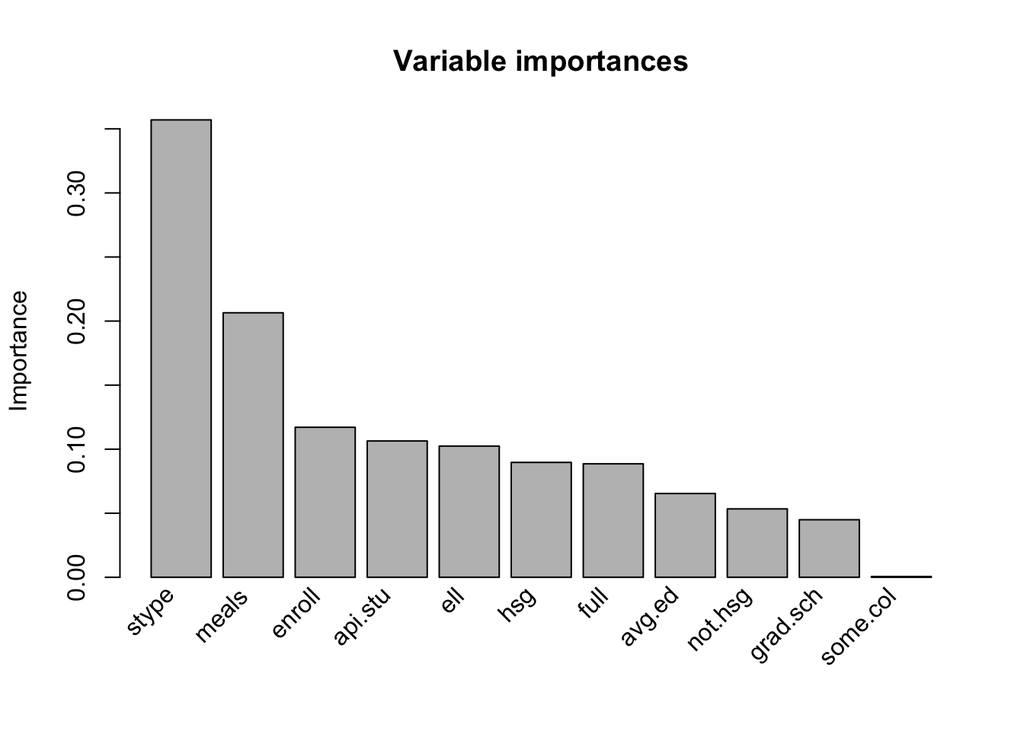

```r
rule.fit.imps$baseimps %>% head(10)
```

[output not shown]

## Part 2: Comparing The Models

> Using the respective models create a table that provides overall accuracy, sensitivity and specificity for predicting if a school qualified for its awards program using the apipop_test1 as the test set for each of the models you derived in parts a-d of Part 1.

```r
y.test <- apipop_test1$awards
cm.table <- data.frame()
```

I will use this function to collect statistics about model’s accuracy and kappa on training and test sets

```r
fill.table <- function(model_name, pred_func, y_train=apipop_train1$awards, y_test = y.test,
                       trainX = apipop_train1,
                       testX = apipop_test1) {
  train.predictions <- pred_func(trainX)
  cm.train = confusionMatrix(train.predictions, y_train)
  test.predictions <- pred_func(testX)
  cm.test = confusionMatrix(test.predictions, y_test)
  return(data.frame(
    model = model_name,
    test.accuracy = cm.test$overall[1],
    test.kappa = cm.test$overall[2],
    train.accuracy = cm.train$overall[1],
    train.kappa = cm.train$overall[2]
  ))
}
```

### a) LASSO model

```r
cm.table <- rbind(cm.table,
  fill.table("LASSO",
           pred_func = function(X) {
             probs = predict(lasso.best.model, newx = data.matrix(X), type = "response")
             as.factor(as.vector(ifelse( probs> 0.5, "Yes", "No")))
}, trainX = apipop_train1[,-1], testX = apipop_test1[,-1])
)
```

### b) OneR

```r
cm.table <- rbind(cm.table,
  fill.table("OneR",
           pred_func = function(X) {
             as.factor(predict(oneR.model, X))
})
)
```

### c) Sequential model

```r
cm.table <- rbind(cm.table,
  fill.table("SeqCover",
           pred_func = function(X) {
             as.factor(predict(seq.model, X))
})
)
```

### d) Rule Fit

```r
cm.table <- rbind(cm.table,
  fill.table("RuleFit",
           pred_func = function(X) {
             probs = predict(rule.fit.model, newdata = X, type = "response")
             as.factor(as.vector(ifelse( probs> 0.5, "Yes", "No")))
})
)
```

### e) Results

```r
rownames(cm.table) <- 1:nrow(cm.table)
cm.table %>% mutate_if(is.numeric, round, digits = 3) %>% arrange(test.accuracy)
```

| model | test.accuracy | test.kappa | train.accuracy | train.kappa |
| --- | --- | --- | --- | --- |
| LASSO | 0.705 | 0.217 | 0.700 | 0.173 |
| OneR | 0.708 | 0.226 | 0.703 | 0.188 |
| RuleFit | 0.712 | 0.256 | 0.719 | 0.248 |
| SeqCover | 0.730 | 0.318 | 0.701 | 0.225 |

As you can see, sequential covering is the best model both in terms of test accuracy and test kappa.

## Part 3: Important Variables

> For every model for which it is appropriate, derive the variable importance measures (feature specific importances, not rule specific importances) and create another table that lists the top 4 most important features for predicting whether a school qualified for it’s award program.

### a) LASSO

```r
lasso.imps <- lasso.best.model %>% coef %>% as.matrix %>% as.data.frame %>%
  slice(-1) %>% abs %>% arrange(desc(s0))
head(lasso.imps)
```

|  | s0 |
| --- | --- |
| stype | 0.375712635 |
| grad.sch | 0.015816183 |
| full | 0.015248647 |
| emer | 0.013521232 |
| meals | 0.007729355 |
| ell | 0.005204630 |

**stype** is the most important variable

### b) One R

```r
oneR.model
```

```
##
## Call:
## OneR.formula(formula = awards ~ ., data = apipop_train1)
##
## Rules:
## If stype = E then awards = Yes
## If stype = H then awards = No
## If stype = M then awards = Yes
##
## Accuracy:
## 3143 of 4474 instances classified correctly (70.25%)
```

As you can see, only **stype** variable is important in oneR model

### c) Sequential Covering

Here is the list of the rules

```r
seq.model
```

```
## JRIP rules:
## ===========
##
## (enroll >= 687) and (stype = H) => awards=No (154.0/48.0)
## (grad.sch <= 9) and (enroll >= 1082) => awards=No (42.0/10.0)
## (enroll >= 600) and (not.hsg >= 24) and (stype = M) => awards=No (48.0/19.0)
## (stype = H) => awards=No (35.0/14.0)
##  => awards=Yes (1220.0/314.0)
##
## Number of Rules : 5
```

The following models enter these rules and are important for making the decisions:

- stype
- enroll
- grad.sch
- not.hsg

### d) Rule Fit

```r
rule.fit.imps <- pre::importance(rule.fit.model, plot = FALSE)
rfi4 <- rule.fit.imps$varimps[1:4, ]
rfi4
```

|  | varname | imp |
| --- | --- | --- |
| 1 | stype | 0.3570190 |
| 2 | meals | 0.2064637 |
| 3 | enroll | 0.1170933 |
| 4 | api.stu | 0.1064105 |

### e) Results

To summarize, all models tell that **stype** is the most important variable. Such variables as **enroll**, **grad.sch**, **meals** are also often present in the list of important predictors.

Here is the table of the most important variables:

```r
cbind(
  data.frame(Lasso = rownames(lasso.imps)[1:4], lasso.imps = lasso.imps[1:4,1]),
  data.frame(oneR = c("stype", NA, NA, NA), oneR.imps = rep(NA, 4)),
  data.frame(SeqCover = c("stype", "enroll", "grad.sch", "not.hsg"), seq.imps = rep(NA, 4)),
  data.frame(RuleFit = rfi4$varname, rule.imps = rfi4$imp)
) %>% select(Lasso, oneR, SeqCover, RuleFit)
```

| Lasso | oneR | SeqCover | RuleFit |
| --- | --- | --- | --- |
| stype | stype | stype | stype |
| grad.sch | NA | enroll | meals |
| full | NA | grad.sch | enroll |
| emer | NA | not.hsg | api.stu |

## Part 4: Random Forest

> Now compute a random forest model to predict whether or not a school qualifies for its awards program (using the training data: apipop_train1) with 750 trees and default value of the mtry parameter. Prior to running the model, set the seed to be 429. Using your model:

```r
set.seed(429)
rf.model <- randomForest(awards ~ ., data = apipop_train1, ntree = 750)
```

Train accuracy and kappa of this model is perfect. By accuracy on the test subset it is not as good:

```r
 cm.table <- rbind(cm.table,
  fill.table("RF",
           pred_func = function(X) {
             predict(rf.model, newdata = X)
})
)
rownames(cm.table) <- 1:nrow(cm.table)
cm.table <- unique(cm.table)
cm.table %>% mutate_if(is.numeric, round, digits = 3) %>% arrange(test.accuracy)
```

| model | test.accuracy | test.kappa | train.accuracy | train.kappa |
| --- | --- | --- | --- | --- |
| LASSO | 0.705 | 0.217 | 0.700 | 0.173 |
| RF | 0.706 | 0.261 | 1.000 | 1.000 |
| OneR | 0.708 | 0.226 | 0.703 | 0.188 |
| RuleFit | 0.712 | 0.256 | 0.719 | 0.248 |
| SeqCover | 0.730 | 0.318 | 0.701 | 0.225 |

### a) Overall Interaction

> create an overall interaction plot that displays the overall H statistic for each of the features.

Here is the code to calculate one-feature H-statistics. Note that the random seed is set to 429 once again. This is how we understand the words “Prior to running the model, set the seed to be 429”

```r
set.seed(429)
suppressPackageStartupMessages(
  predictor1 <-  Predictor$new(rf.model, dat = apipop_test1, y = apipop_test1$awards)
)
suppressPackageStartupMessages(
  rf.interaction1 <- Interaction$new(predictor1)
)
```

```r
rf.interaction1$results %>% head(8)
```

| .feature | .class | .interaction |
| --- | --- | --- |
| awards | No | 0.0007475464 |
| awards | Yes | 0.0007475464 |
| stype | No | 0.4971598252 |
| stype | Yes | 0.4971598252 |
| meals | No | 0.3046433023 |
| meals | Yes | 0.3046433023 |
| ell | No | 0.5526520105 |
| ell | Yes | 0.5526520105 |

As you can see, the number of h-statistics values is doubled (two values for each feature, corresponding to award = “Yes” and “No”). It turns out, however, that these values are exactly the same

```r
as.data.frame(rf.interaction1$results) %>%
  tidyr::pivot_wider(names_from = .class, values_from = .interaction) %>%
  mutate(ratio = Yes/No) %>%
  head(10)
```

| .feature | No | Yes | ratio |
| --- | --- | --- | --- |
| awards | 0.0007475464 | 0.0007475464 | 1 |
| stype | 0.4971598252 | 0.4971598252 | 1 |
| meals | 0.3046433023 | 0.3046433023 | 1 |
| ell | 0.5526520105 | 0.5526520105 | 1 |
| mobility | 0.3851307362 | 0.3851307362 | 1 |
| pct.resp | 0.3140788948 | 0.3140788948 | 1 |
| not.hsg | 0.3794202484 | 0.3794202484 | 1 |
| hsg | 0.3933387624 | 0.3933387624 | 1 |
| some.col | 0.2871200287 | 0.2871200287 | 1 |
| col.grad | 0.4939960623 | 0.4939960623 | 1 |

For this reason I will be interested only in .class = “Yes” part

Here is the plot

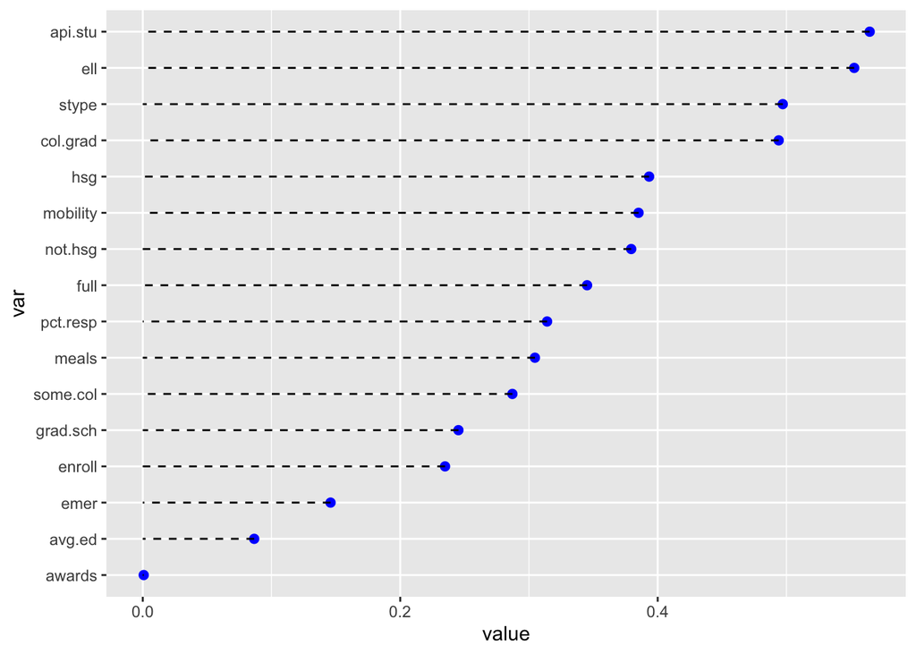

```r
h.res <- data.frame(rf.interaction1$results) %>%
  filter(.class=="Yes") %>%
  transmute(var=.feature, value=.interaction) %>%
  arrange(value) %>%
  mutate(var = factor(var, levels = var))
ggplot(h.res, aes(y=var, yend=var, xend = 0, x=value)) + geom_point(color = "blue", cex = 2) +
  geom_segment(linetype = 2)
```

As you can see, **api.stu** has the largest H-score.

### b) API.STU interactions

> Using the feature with the highest overall H statistic, create an additional plot that shows the H statistics related to this specific feature

```r
suppressPackageStartupMessages(
  interactAPI <- Interaction$new(predictor1, feature = "api.stu")
)
```

Again, we have to identical sets of the statistics, here is ordered plot of one of them:

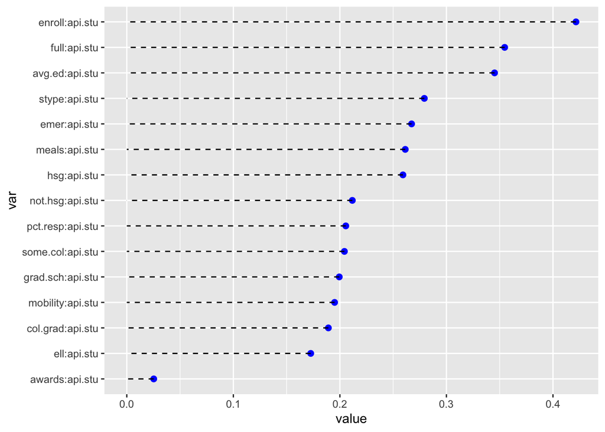

```r
h2.res <- data.frame(interactAPI$results) %>%
  filter(.class=="Yes") %>%
  transmute(var=.feature, value=.interaction) %>%
  arrange(value) %>%
  mutate(var = factor(var, levels = var))
ggplot(h2.res, aes(y=var, yend=var, xend = 0, x=value)) + geom_point(color = "blue", cex = 2) +
  geom_segment(linetype = 2)
```

### c) Comparison with Rule-Fit

> Is the information in the second plot consistent with the some of the rules the Rule Fit model is reporting? Why or why not?

As you can see, the highest h-statistic value here is for **api.stu : enroll** interaction. For Rule Fit model there are two rules, containing both of these variables.

```r
rule.fit.imps$baseimps %>%
  filter(grepl("enroll", description) & grepl("api.stu", description))
```

[output not shown]

### d) H-Statistics

> What is the H-statistic value corresponding to the variables included in the top- most important rule in the rule fit model that involves only two predictors? (Be sure to indicate what the top-most important rule with two features is from your rule fit model, along with it’s importance) as well as the plot of that rule from the RuleFit model.

```r
rule.fit.imps$baseimps %>% arrange(desc(imp)) %>% head(10)
```

[output not shown]

It includes interaction of two variables, that we saw in the previous section, so the picture is consistent.

**NB: In the previous version of this notebook we have used the other random seed number before evaluating overall H-score (see first code chunk in subsection 1-4a). With this choice of random seeds important interactions were different. So, it can be assumed that mentioned above consistency was only accidental, it is not stable**